# BISC-305 Discussion #2

09/09/2019

# Exercise 1: Trojan’s Scores Boxplot

Q: Trojans’ score for the last season are as follows: 43, 3, 14, 39, 24, 31, 28, 35, 38, 14, 27, 17. We want to make a boxplot and see if there are any outliers. Repeat this with Example 2.4.2 in your textbook about pulses of 12 college patients: 43, 3, 14, 39, 24, 31, 28, 35, 38, 14, 27, 17

```r
trojans.score <- c(43, 3, 14, 39, 24, 31, 28, 35, 38, 14, 27, 17)
# c(43, 3, 14, 39, 24, 31, 28, 35, 38, 14, 27, 17)
```

# Excercise 2: Scatter plot

For this and the next excercice we will be using the `mtcars` dataset that comes with `R`. It comprises of fuel consumption and 10 aspects of automobile design and performance for 32 automobiles (1973–74 models). You can get alist of all datasets available inside `R` using `data()` command.

## Q: Can you determine which variables are categorical and which are numerical (continous/discontinous)?

Variables and their description:

```
[, 1]   mpg Miles/(US) gallon
[, 2]   cyl Number of cylinders
[, 3]   disp    Displacement (cu.in.)
[, 4]   hp  Gross horsepower
[, 5]   drat    Rear axle ratio
[, 6]   wt  Weight (1000 lbs)
[, 7]   qsec    1/4 mile time
[, 8]   vs  Engine (0 = V-shaped, 1 = straight)
[, 9]   am  Transmission (0 = automatic, 1 = manual)
[,10]   gear    Number of forward gears
[,11]   carb    Number of carburetors
```

## Q: What is the relationship between the weight of the car and the mileage?

`ablines` command in `R` draws a straight line. `lines` command is a generic function to draw a curve passing it the coordinates. `lty` parameter determines the line type (1-continuous, 2-dashed).

## Q: How does the shape of the engine (vs) vary across the number of gears (gear)?

## Q: How does the 1/4 mile time (qsec) vary across Transmission (am) types?

## Bonus Q: Is their a difference between the gross horsepower of the cars with manual vs those with automatic transmission?

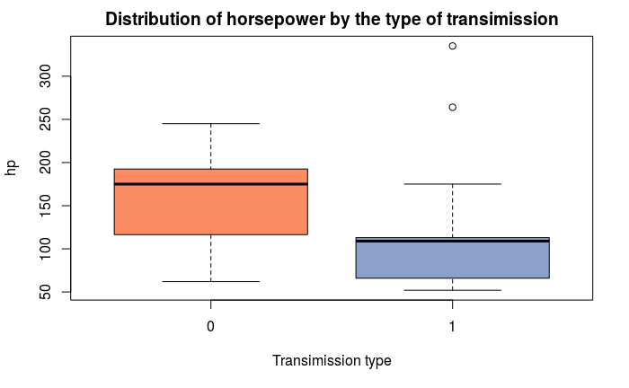